# Individual course project (specifications)

# Principle

The aim of the project is to allow the students to showcase their know-how on **data science** and **machine learning**, in a $\textsf{R}$ **coding context**. To this purpose, we propose 4 datasets that the students can work on (choose only one!)

1. **credit scoring**:
   - **classification exercise** in which the aim is to predict the first (binary) column (bankruptcy) from this [RData file (3.5Mo)](https://drive.google.com/file/d/1EDLZTbByCqf6nb0cjhMri2UtYD8FFL1b/view?usp=share_link) - 6819 rows for 96 columns.
   - **source**: [Kaggle](https://www.kaggle.com/datasets/fedesoriano/company-bankruptcy-prediction), CSV file of 11.5Mo.
2. **fraud detection**:
   - **classification task** too here, where we want to forecast if a transaction is fraudulent (column *isFraud*) from this [RData file (82Mo)](https://drive.google.com/file/d/1ZqlRrTUZNao-I1lZNVztf206vp8QUkqV/view?usp=share_link): 590k rows, ~400 columns. Be careful, this project requires computation power BUT you can work on a subset of it: this dataset is not clean, hence removing missing data will lighten the size (see course code). Cleaning stage = bonus points.
   - **source**: [Kaggle](https://www.kaggle.com/c/ieee-fraud-detection), CSV but 652Mo!
3. **stock market prediction**:
   - here the objective is of **regression type**, as the aim is to predict stock returns from panel-type data. They are the last column of this [RData file (8Mo)](https://drive.google.com/file/d/12i9NQpbPpHH8hvTuCw4LdoKY7njaRShW/view?usp=share_link) (clean only, raw available upon request). It contains monthly observations of financial data for ~900 US firms from 1995 to 2023: 10 predictors in final, including greenhouse gas emission scopes (starting in 2011). 280k rows for 13 columns.
4. **Venture capital funding**:
   - **classification problem**, the aim is to predict the *VC* binary column that codes if the firm received capital during the year 2000. All variables are listed below. The small dataset [RData file (160ko)](https://drive.google.com/file/d/1zseloQ1a35-Fgg4Z1Gnw29ZU7LKHLs9w/view?usp=sharing) has not been cleaned (there are missing points).

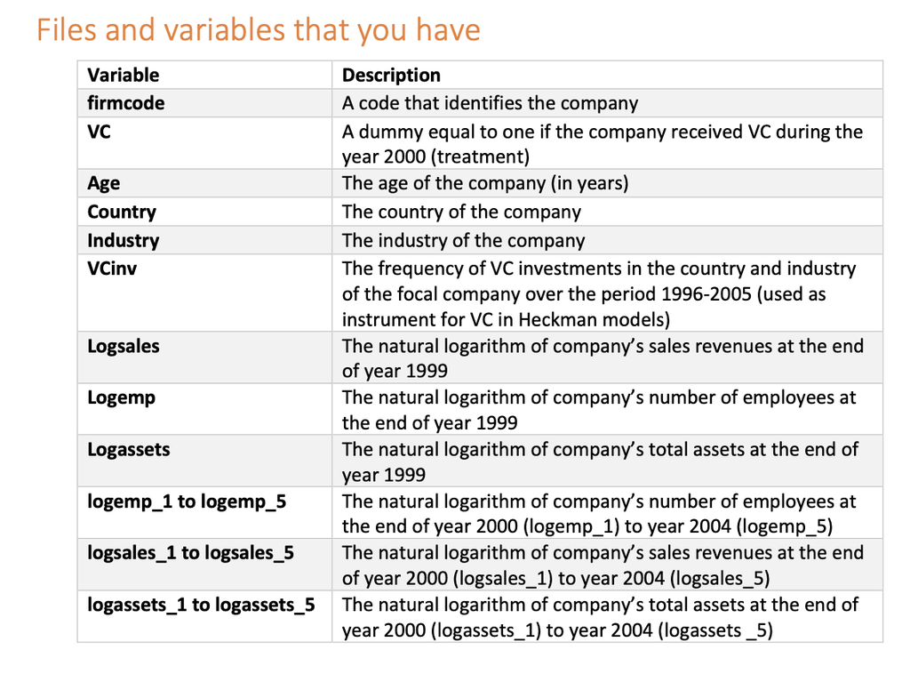

In addition, we leave open the option for students to work with other datasets, **BUT THIS WILL NEED TO BE APPROVED BY THE PROFESSOR**. In that case, the students must provide the data, ideally in .RData format (lighter & better optimized).

# Content

In terms of **data science tasks**, pivot-tables are a must do, with ideally some plotting with [**ggplot**](https://ggplot2.tidyverse.org/) (see also the [book](https://ggplot2-book.org/)).

With regards to **machine learning tasks**, the student can split the sets into several parts for the purpose of training/validating/testing as they wish. The can use the algorithmic families they want (tree-based, neural networks, etc.). Unsupervised learning analyses are also welcome if students wish.

**ORIGINALITY** will be rewarded: please make sure your projects are as far as possible from those of your comrades!

# Expected outcome

The expected outcome consists in **2 notebooks**:

- one in **source code** .Rmd (RMarkdown) OR .qmd (Quarto)
- one in **html** (knitted/compiled version)

⏮ **Comments** OUTSIDE the code chunks are **strongly** expected, especially when it comes to **interpreting** the results they generate. Code on its own is useless: I want to be sure you understood fully what you coded! Comments are here for this. Comment as much as possible (not only in code chunks!).

If you have resorted to **chatGPT**, make sure you mention for which part you have used it (e.g., graphs, oversampling, debugging, etc.).  
**NOTE**: chatGPT has a particular way to code, which is sometimes easy to spot…

The deadline is **2024-04-05**.

# Checklist

Before uploading your work, please make sure you:

- ✅ have quit R, re-opened your notebook and executed all your code to make sure it works (**IMPORTANT**)
- ✅ have a load(“…”) call in the notebook that loads the data
- ✅ have included datasets if they are not the ones provided
- ✅ have commented all results/outputs.
- ✅ have **zipped all your files** together (.Rmd or .qmd + .html)